# Theory of Statistical Inference (MT5017) (H & B, Chapter 6)

## Frequentist and Subjective Probability

Let \(A\) denote an event; \(P(A)\) is:

- **Frequentist**: The event \(A\) is a possible outcome of a repeatable random experiment; \(P(A)\) is obtained as the empirical proportion of experiments in which \(A\) occurs.
- **Subjective**: \(P(A)\) is a personal measure of how likely it is that \(A\) will occur.

## Frequentist and Bayesian Statistics

We want to make a statement about the value of an unknown parameter \(\theta_0\in\Theta\)

- **Frequentist**: Before observing the data, I only know that \(\theta_0\in\Theta\).
- **Bayesian**: Before observing the data, my knowledge about the value of \(\theta_0\) can be described by a probability density function \(p_\theta(\cdot)\), the *prior distribution*.

## Frequentist and Bayesian Statistics

We want to make a statement about the value of the unknown parameter \(\theta_0\in\Theta\) after observing \(x\), a realization of \(X\sim P_{\theta_0}\)

- **Frequentist**: My estimate of \(\theta_0\) is \(\hat{\theta}(x)\), and the uncertainty in my method is described by \(\hat{\theta}(X)\), where \(X\sim P_\theta\).
- **Bayesian**: My knowledge of the value of \(\theta_0\) is now updated to the conditional density \(p_{\theta|X}(\cdot|x)\) for \(\theta|X=x\), the *posterior distribution*.

## Bayes Theorem

If we interpret \(p_{X|\theta}(x|\theta)\) as the conditional density of \(X|\theta\), we can determine the posterior distribution

\[ p_{\theta|X}(\cdot|x)=\frac{p_{X|\theta}(x|\cdot)p_\theta(\cdot)}{p_X(x)}\propto p_{X|\theta}(x|\cdot)p_\theta(\cdot) \]

## Example: Quality control prior distribution

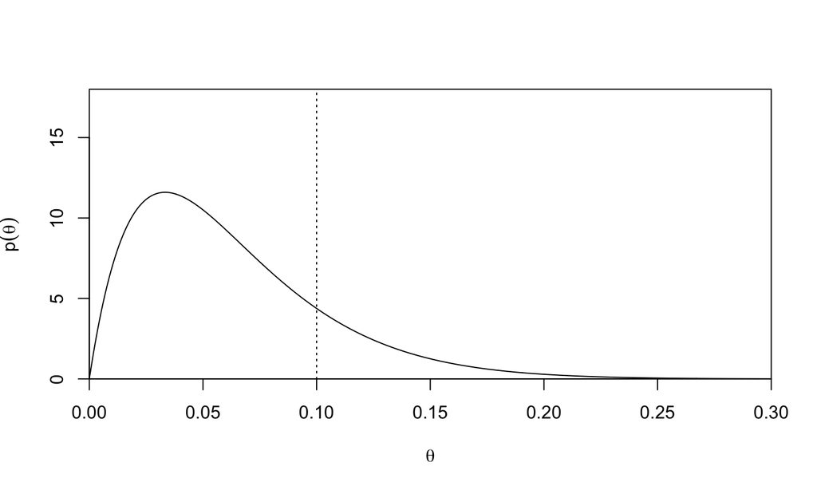

## Example: Quality control posterior distribution

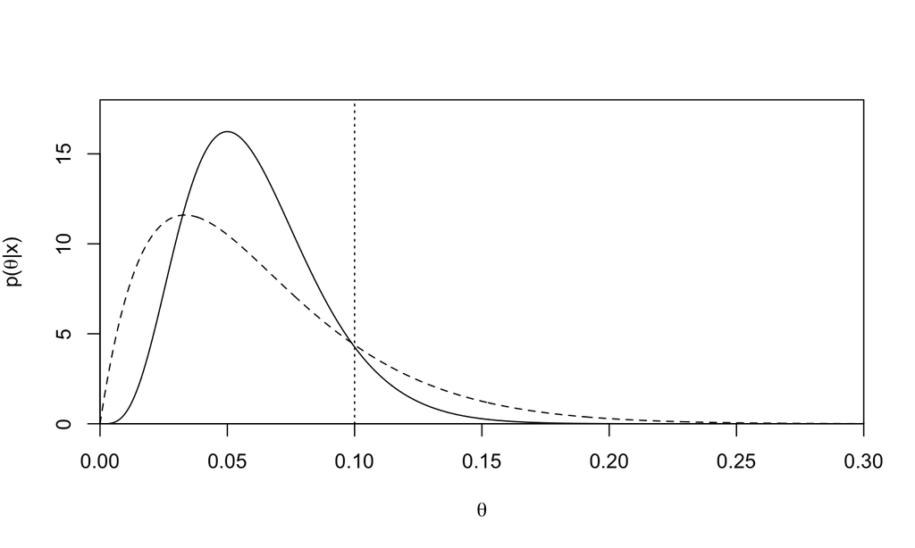

## Example: Quality control

\(P(\theta>0.1)\)

```r
1 - pbeta(0.1, 2, 30)
```

```
## [1] 0.1695646
```

\(P(\theta>0.1|X=3)\)

```r
1 - pbeta(0.1, 5, 77)
```

```
## [1] 0.08270474
```

## Examample: Lifespans prior distribution

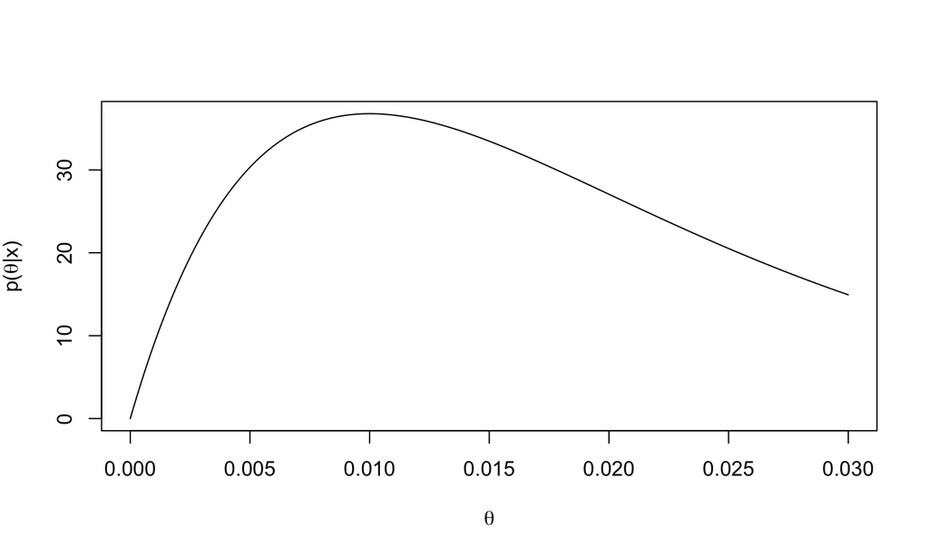

## Examample: Lifespans posterior distribution

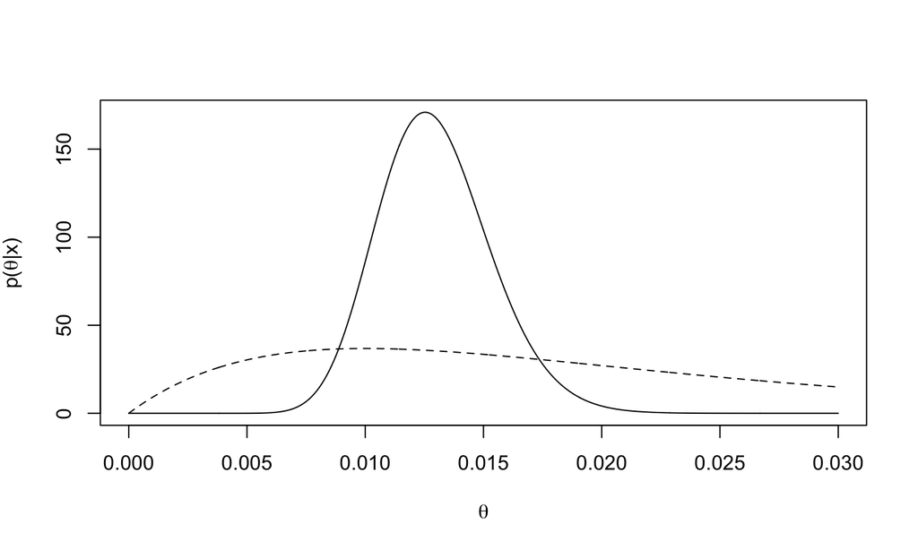

## Examample: Lifespans, central tendency

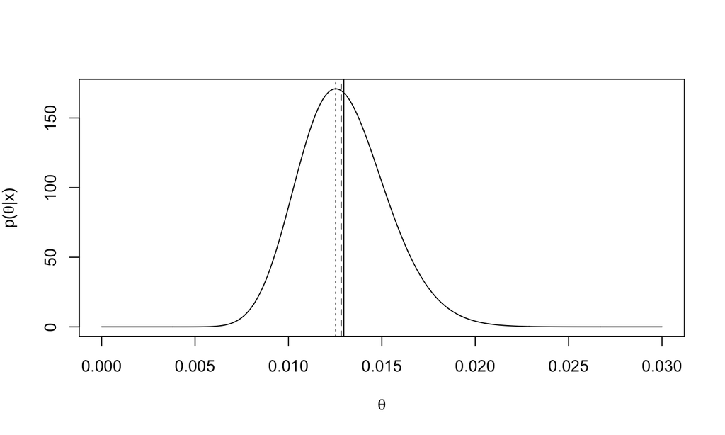

## Examample: Lifespans, credible interval

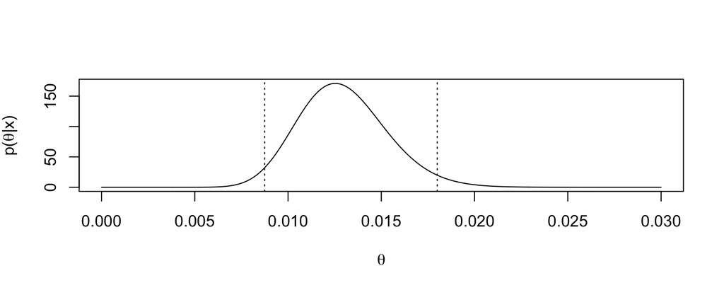

```r
qgamma(c(0.025, 0.975), 30, sum(ac) + 100)
```

```
## [1] 0.008747137 0.017998633
```

## Choice of Prior Distribution

## Conjugate Family

**Definition:** (H & B, definition 6.5) A family of distributions \(G\) is said to be conjunctive with respect to a likelihood function \(L(\theta)=p(x|\theta)\) if \(p(\theta|x)\in G\) whenever \(p(\theta)\in G\).

## Jeffreys prior

**Definition:** (H & B, definition 6.7) Given a likelihood \(L(\theta)\), the Jeffreys prior distribution is given by \[ p(\theta)\propto \sqrt{J(\theta)}. \]

## Jeffreys prior, Binomial likelihood

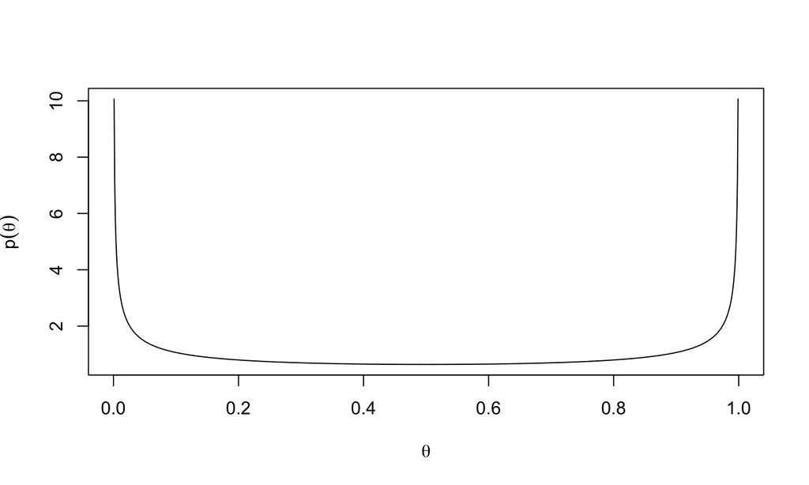

## Vector-valued parameters

- Frequentists plug in…
- Bayesians integrate out:

\[ p(\theta|x)=\int p(\theta, \eta|x)\, d\eta. \]

## Treevolumes, posterior distribution

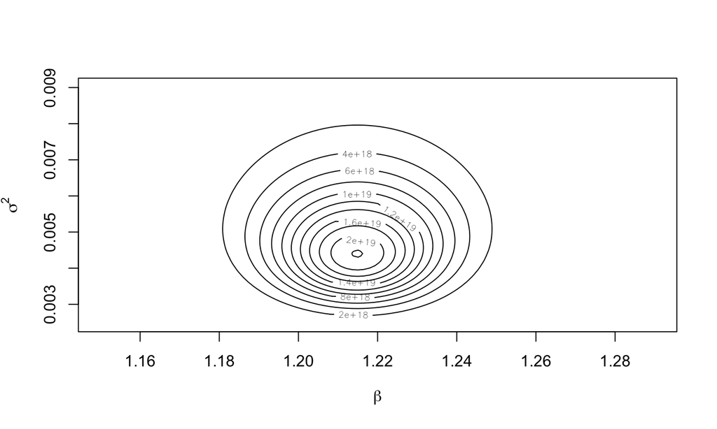

## Treevolumes, posterior distribution for \(\beta\)

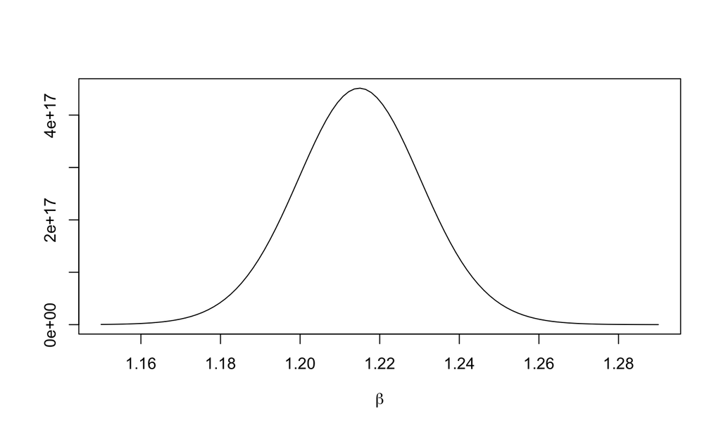

## Monte Carlo Methods

- Difficult to integrate analytically.
- If we can simulate from \(\phi=(\theta, \eta)\sim p_\phi(\cdot|x)\), we can also simulate from \(\theta\sim p_\theta(\cdot|x)\).
- Difficult to simulate directly from \(p_\phi(\cdot|x)\), but easy to simulate a Markov process with \(p_\phi(\cdot|x)\) as the stationary distribution…

## Metropolis-Hastings (Random Walk)

Choose an initial value \(z_0\).

\(z_1, \ldots, z_N\) now form a sample from a Markov process with stationary distribution \(f\).

## MH, Weibull

```r
post <- function(theta){L.weib(theta[1], theta[2], data = ac)}
N <- 10000 #Number of iterations
theta <- matrix(nrow = N, ncol = 2)
theta[1,] <- c(1, 0.01) # Initial value
sigma <- c(0.1, 0.001) # Step length
for (i in 2:N){
  theta.star <- theta[i-1,] + rnorm(2) * sigma
  if (post(theta.star) / post(theta[i-1,]) > runif(1))
    theta[i,] <- theta.star
  else
    theta[i,] <- theta[i-1,]
}
```

## MH, Weibull

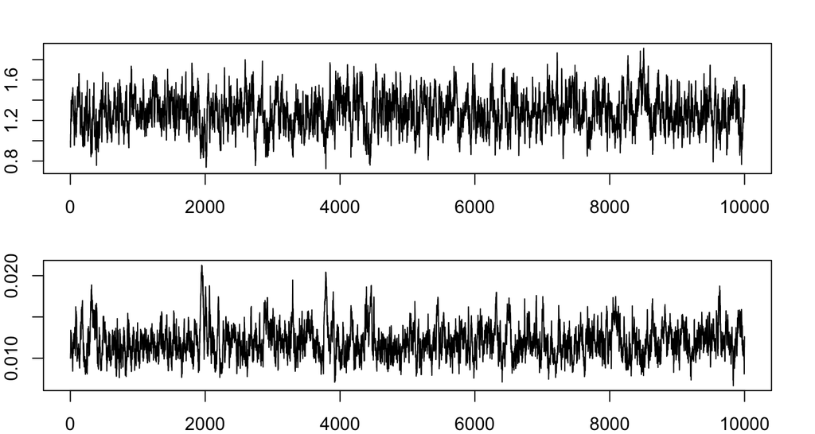

## MH, Weibull

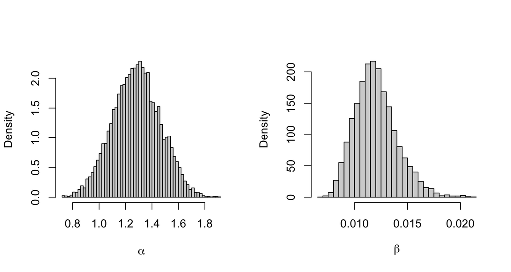

## MH, Weibull

Probability that average time between failures is larger than 100 hours:

```r
mean(1 / theta[,2] > 100)
```

```
## [1] 0.1523
```

Probability that the aggregat lasts longer than 100 hours:

```r
TT <- rweibull(N, theta[, 1], scale = 1 / theta[, 2])
mean(TT > 100)
```

```
## [1] 0.2977
```

## MH, long steps

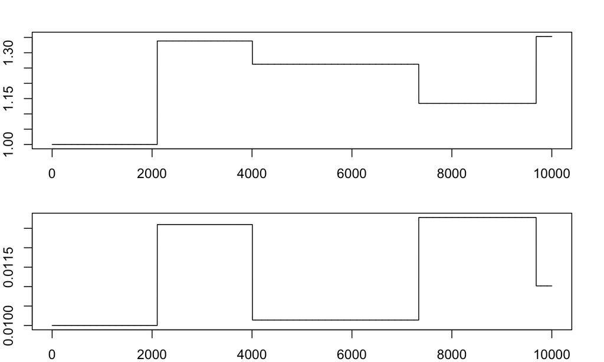

## MH, short steps

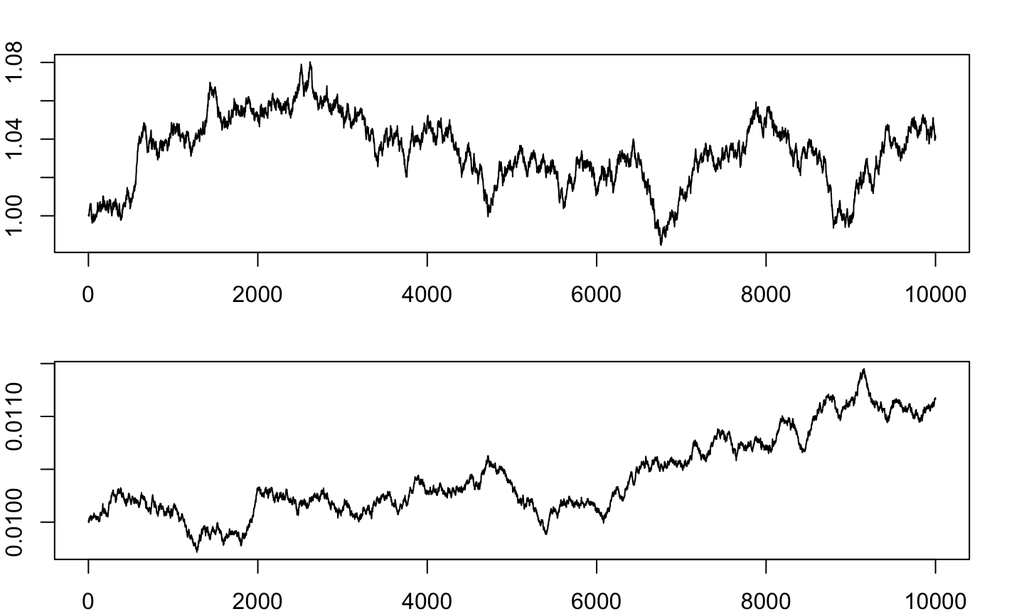

## Summary: Bayesian vs. Frequentist

- As a frequentist, you don’t have to specify a prior distribution, but you often have to rely on asymptotic results.
- As a Bayesian, you don’t have to refer to asymptotics, but you have to rely on your prior distribution.